# Empleo, vivienda y demografía en Canarias

Álvaro Ginés Gómez Delgado

2026-10-04

[figure not shown]

[Cuadro de mandos](http://10.22.143.222:3838/sample-apps/a2405/Dashboard3.Rmd)

# 1 Introducción

## 1.1 Estado actual

### 1.1.1 Estado del arte del tema

Canarias presenta una estructura económica singular dentro de España, caracterizada por su lejanía insular, alta dependencia del turismo y la construcción, y un mercado laboral con estacionalidad marcada. La crisis de 2008 afectó severamente al archipiélago, con una destrucción de empleo superior a la media nacional y una recuperación más lenta. Estudios previos (ISTAC, 2023; Banco de España, 2022) señalan que la convergencia en renta per cápita se ha estancado desde 2010. Los datos del ISTAC permiten analizar ocho dimensiones clave —empleo, vivienda, construcción, inversión, demografía, salud, precios y energía— con cobertura municipal/islas/CCAA y series largas (1999–2026), ofreciendo una oportunidad única para un análisis integrado multiescalar.

### 1.1.2 Estado actual del proyecto (Entregas 1–3)

**Estado de las entregas del proyecto**

| Entrega | Estado | Qué se ha completado |
| --- | --- | --- |
| **Entrega 1** (Validación tema y datasets) | ✅ **Completada** | P1–P5 definidas; 8 indicadores ISTAC validados (≥4 AEDV); estrategia IA documentada; Google Sheet operativo. |
| **Entrega 2** (Entrega intermedia) | 🔄 **En curso** | Comprensión/Preparación/Modelado/Evaluación preliminares; gráficas ggplot2; diagnóstico residuos y AICc. |
| **Entrega 3** (Entrega final) | ⏳ **Pendiente** | Validación out-of-sample; gráficas Plotly; dashboard DIS (series facet_wrap, mapas, PCA, ARIMA); Conclusiones P1–P5; Bibliografía; Anexos I–II. |

## 1.2 Motivación

Mi vinculación con Canarias es personal y familiar: nací y resido en Las Palmas de Gran Canaria, y he vivido directamente la volatilidad del mercado laboral canario y la presión sobre la vivienda. Profesionalmente, el análisis de datos socioeconómicos locales permite aportar evidencia para la toma de decisiones en planificación territorial, políticas de empleo y vivienda. La oportunidad surge de la disponibilidad reciente (2024–2026) de series actualizadas mensuales/trimestrales en el ISTAC que no existían en convocatorias anteriores, permitiendo capturar la recuperación post-COVID y la inflación 2022–2023 con granularidad municipal.

## 1.3 Objetivos

**Objetivo general:** Analizar la evolución conjunta de empleo, vivienda, demografía y sectores productivos en Canarias (1999–2026) para identificar patrones de convergencia/divergencia interna y respecto a España, y construir modelos predictivos de corto plazo.

**Objetivos específicos:** 1. Identificar las principales variables que explican la dinámica empleo-población a nivel municipal en Canarias (2012–2025). 2. Comparar la evolución de la vivienda iniciada y la inversión bruta en Canarias frente al resto de CCAA, evaluando el ciclo inmobiliario. 3. Modelar y predecir series temporales clave (afiliaciones, IPC, cemento, gasóleo) mediante ARIMA/STL para horizonte 2025–2026. 4. Diseñar un cuadro de mandos interactivo (Shiny, servidor DIS) que permita explorar series temporales, mapas coropléticos, PCA y correlaciones con selección dinámica de variables.

**Preguntas de investigación:**

- **P1:** ¿Se ha recuperado el empleo en Canarias tras la crisis de 2008 al mismo ritmo que en el resto de comunidades? ¿Qué municipios/islas muestran mayor rezago?
- **P2:** ¿Qué relación existe entre la evolución de la vivienda iniciada y la inversión bruta en Canarias vs. España? ¿Hay desajuste oferta-demanda?
- **P3:** ¿Cómo ha evolucionado la dinámica empleo-población a nivel municipal en Canarias (2012–2025)? ¿Hay municipios en declive demográfico con empleo creciente o viceversa?
- **P4:** ¿Qué islas dependen más de un solo sector (construcción/turismo) y cómo afectó esa dependencia a su resiliencia económica tras 2008 y 2020?
- **P5:** ¿Qué nivel de afiliaciones/empleo cabe esperar en los próximos dos años según modelos ARIMA? ¿Y el IPC y el precio del gasóleo?

# 2 Aportaciones del trabajo

## 2.1 Principales aportaciones

Se espera que este proyecto aporte las siguientes contribuciones al conocimiento de la dinámica socioeconómica y demográfica de Canarias:

1. **Análisis integrado multiescalar (municipal–insular–CCAA)** de ocho indicadores clave (empleo, vivienda, construcción, inversión, población, salud, precios, energía) con series temporales homogéneas 1999–2026, permitiendo comparar la evolución interna de Canarias y su posicionamiento frente al resto de España.
2. **Identificación de tipologías municipales** según su trayectoria empleo-población 2012–2025 (crecimiento sostenido, estancamiento, declive demográfico con empleo resiliente, etc.), mediante técnicas de agrupamiento y series temporales, aportando una clasificación operativa para políticas territoriales.
3. **Evidencia cuantitativa del desajuste vivienda-inversión** en Canarias vs. España: se compara la evolución de VIVIENDAS_INICIADAS e INVERSION_ESPANOLA_BRUTA para detectar períodos de sobreoferta/suboferta residencial y su relación con el ciclo económico.
4. **Modelos predictivos ARIMA/STL validados** para series clave (afiliaciones, IPC, cemento, gasóleo) con horizonte 2025–2026, incluyendo intervalos de confianza y diagnóstico de residuos, útiles para planificación de corto plazo.
5. **Cuadro de mandos interactivo (Shiny, servidor DIS)** que permite explorar dinámicamente: series temporales con `facet_wrap` por municipio/isla/CCAA y selección múltiple de atributos; mapas coropléticos municipales/insulares; matriz de correlación y biplot PCA con variables seleccionables; y panel de predicción ARIMA con parámetros editables. Todas las variables se controlan mediante `selectInput`/`sliderInput` dinámicos, sin valores hardcodeados.

## 2.2 Alineamiento con los objetivos de desarrollo sostenible

Grado de relación del proyecto con los objetivos de desarrollo sostenible (ODS)

| ODS | No procede | Bajo | Medio | Alto |
| --- | --- | --- | --- | --- |
| ODS 1. Fin de la pobreza |  |  | X |  |
| ODS 2. Hambre cero | X |  |  |  |
| ODS 3. Salud y bienestar |  |  |  | X |
| ODS 4. Educación de calidad | X |  |  |  |
| ODS 5. Igualdad de género | X |  |  |  |
| ODS 6. Agua limpia y saneamiento | X |  |  |  |
| ODS 7. Energía asequible y no contaminante |  |  | X |  |
| ODS 8. Trabajo decente y crecimiento económico |  |  |  | X |
| ODS 9. Industria, innovación e infraestructura |  |  | X |  |
| ODS 10. Reducción de las desigualdades |  |  | X |  |
| ODS 11. Ciudades y comunidades sostenibles |  |  | X |  |
| ODS 12. Producción y consumo responsables | X |  |  |  |
| ODS 13. Acción por el clima |  | X |  |  |
| ODS 14. Vida submarina | X |  |  |  |
| ODS 15. Vida de ecosistemas terrestres | X |  |  |  |
| ODS 16. Paz, justicia e instituciones sólidas | X |  |  |  |
| ODS 17. Alianzas para lograr los objetivos | X |  |  |  |

El proyecto se relaciona directamente con **ODS 8 (Trabajo decente y crecimiento económico)** como relación **Alta**, al analizar la evolución del empleo asalariado (AFILIACIONES_ASALARIADOS) a nivel municipal en Canarias, su recuperación tras las crisis de 2008 y 2020, y su vínculo con la dinámica poblacional. **ODS 3 (Salud y bienestar)** también tiene relación **Alta** mediante el análisis de defunciones por cáncer (DEFUNCIONES_CANCER) por isla, permitiendo identificar disparidades territoriales en mortalidad oncológica.

Con relación **Media**: **ODS 1 (Fin de la pobreza)** — el empleo es el principal determinante de la renta familiar; **ODS 7 (Energía asequible)** — serie de precios del gasóleo (HIDROCARBUROS_PRECIO_GASOLEO) como indicador de costes energéticos y movilidad; **ODS 9 (Industria, innovación e infraestructura)** — ventas de cemento (CEMENTO_VENTAS) y viviendas iniciadas (VIVIENDAS_INICIADAS) reflejan actividad constructora e infraestructura residencial; **ODS 10 (Reducción de desigualdades)** — el análisis municipal revela brechas intrainsulares en empleo y población; **ODS 11 (Ciudades y comunidades sostenibles)** — dinámica vivienda-población y presión residencial en municipios turísticos. **ODS 13 (Acción por el clima)** tiene relación **Baja** indirecta a través del precio de carburantes como proxy de intensidad de carbono en el transporte.

# 3 Desarrollo

## 3.2 Metodología

Utilizaremos la metodología de desarrollo CRISP-DM (Cross Industry Standard Process for Data Mining), un marco ampliamente utilizado para proyectos de Ciencias de Datos. En la siguiente figura se presenta un diagrama con las diferentes fases de esta metodología que a continuación describimos con más detalle:

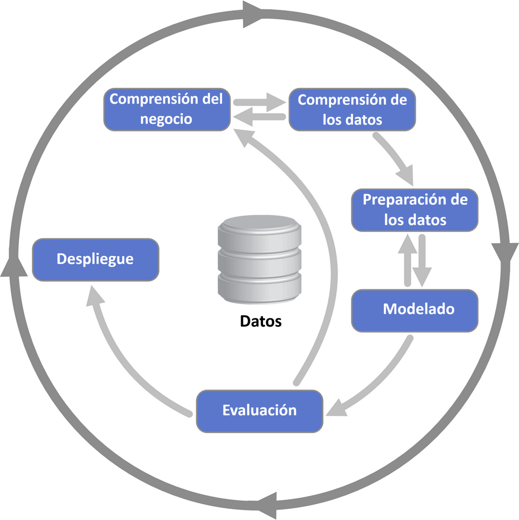

*Figura 2. Diagrama de la metodología de desarrollo CRISP-DM.*

- **Comprensión del negocio**. A partir de los objetivos y las preguntas de investigación del proyecto, se realiza la búsqueda y evaluación de fuentes de información y datos, y se describe la estrategia seguida para seleccionar los datasets, incluido el uso de la IA.
- **Comprensión de los datos**. Se analiza la estructura y organización de los datos obtenidos. Se identifican posibles problemas como datos faltantes, outliers o inconsistencias.
- **Preparación de los datos**. Se realizan limpieza, transformación, combinación y selección o creación de variables relevantes para el análisis.
- **Modelado**. Se seleccionan y aplican los modelos adecuados para analizar los datos.
- **Evaluación**. Se evalúa si el modelo responde a las preguntas de investigación y se compara con otros métodos cuando procede.
- **Despliegue**. Se comunica el trabajo mediante esta memoria y se diseña un cuadro de mandos para presentar los resultados de forma eficaz y atractiva.

Es importante observar que esta metodología es **iterativa**: los resultados obtenidos en fases avanzadas pueden requerir revisar y ajustar fases anteriores. A continuación se describe en detalle cómo se ha abordado cada fase.

## 3.3 Comprensión del negocio

## 3.4 Comprensión de los datos

**Inclusión datasets**

## 3.5 Comprensión de los datos

### 3.5.1 1. Descripción de las variables

La API del ISTAC devuelve todos los indicadores en formato **tidy**: una fila por observación con cinco columnas estructurales.

[output not shown]

**Detalle por indicador:**

| INDICATOR | Ámbito | Frec. | Unidad | Qué mide |
| --- | --- | --- | --- | --- |
| `AFILIACIONES_ASALARIADOS` | Empleo | M | personas | Afiliados a la Seguridad Social como asalariados |
| `CEMENTO_VENTAS` | Construcción | M | toneladas | Ventas de cemento en el mercado interior |
| `INVERSION_ESPANOLA_BRUTA` | Economía | Q | millones € | Formación bruta de capital fijo (residentes en España) |
| `VIVIENDAS_INICIADAS` | Vivienda | M | número | Viviendas cuyo inicio de obra se certifica |
| `POBLACION` | Demografía | Y | personas | Población residente (padrón municipal) |
| `DEFUNCIONES_CANCER` | Salud | Y | número | Defunciones por neoplasias (CIE-10 C00–D48) |
| `IPC` | Precios | M | índice 2016=100 | Índice de Precios de Consumo general |
| `HIDROCARBUROS_PRECIO_GASOLEO` | Energía | W | €/litro | Precio medio de venta al público del gasóleo A |

### 3.5.2 2. Estructura de los datos: ¿SON TIDY?

**Sí.** Cada fila = una observación única (territorio × indicador × periodo).  
No hay columnas anchas (p. ej., `2020`, `2021`, `2022`); la dimensión temporal está en `TIME`.  
La dimensión indicador está en `INDICATOR` (formato *long*).  
La dimensión geográfica está normalizada en `GEOGRAPHICAL` + `NAME`.

### 3.5.3 3. Tamaño y cobertura del dataset combinado

[output not shown]

**Observaciones por indicador (aprox.):**

| INDICATOR | n.reg | Periodos/reg (P25) | Total filas |
| --- | --- | --- | --- |
| AFILIACIONES_ASALARIADOS | 97 | 545 | ~53 000 |
| CEMENTO_VENTAS | 8 | 1 135 | ~9 100 |
| INVERSION_ESPANOLA_BRUTA | 21 | 830 | ~17 400 |
| VIVIENDAS_INICIADAS | 63 | 1 185 | ~74 600 |
| POBLACION | 97 | 26 | ~2 500 |
| DEFUNCIONES_CANCER | 8 | 78 | ~600 |
| IPC | 20 | 885 | ~17 700 |
| HIDROCARBUROS_PRECIO_GASOLEO | 8 | 1 190 | ~9 500 |

### 3.5.4 4. Atributos combinados (territorio × indicador)

- **MUNI (97)**: `AFILIACIONES_ASALARIADOS`, `POBLACION` → combinación completa 97 × periodos.
- **ISLA (8)**: `CEMENTO_VENTAS`, `DEFUNCIONES_CANCER`, `HIDROCARBUROS_PRECIO_GASOLEO` → 8 × periodos cada uno.
- **CCAA (21/20/63)**: `INVERSION_ESPANOLA_BRUTA` (21), `IPC` (20), `VIVIENDAS_INICIADAS` (63) → cada indicador cubre su ámbito CCAA respectivo.
- No hay combinaciones cruzadas entre indicadores en la tabla cruda; la unión se hace en fase de análisis mediante `left_join` por `GEOGRAPHICAL` + `TIME`.

### 3.5.6 6. Problemas identificados (diagnóstico, sin decisiones)

[output not shown]

> **Nota**: Esta sección describe los datos *tal como se descargan* de la API del ISTAC. Las decisiones de limpieza, homogeneización de frecuencias, tratamiento de NA, encadenamiento de series y fusión territorial se documentan en la fase **Preparación de los datos**.

## 3.6 Preparación de los datos

## 3.7 Modelado

## 3.8 Evaluación

## 3.9 Despliegue

# 4 Conclusiones y trabajo futuro

## 4.1 Conclusiones

## 4.2 Trabajo futuro

# Bibliografía

[[Al26](https://luisalvarezmat-aedv.share.connect.posit.cloud/)] Álvarez Luis. *Análisis Exploratorio de Datos y Visualización*, posit.cloud, 2026. (diversas consultas entre el Enero Septiembre y Diciembre d 2026)

# Anexo I. Agentes de IA utilizados y organización del trabajo con la IA

## Herramientas y agentes IA utilizados

| Agente | Coste | Uso principal |
| --- | --- | --- |
| **Hermes Agent** (NVIDIA Nemotron 3 Ultra) | Gratuito | Orquestación del proyecto, edición de memoria, coordinación de agentes |
| **Claude Code CLI** (Anthropic) | Suscripción Pro/Max | Desarrollo de código R, depuración, automatización CRISP-DM |
| **Claude (Sonnet 4.5)** | Gratuito | Depuración de código R y redacción de la memoria |
| **ChatGPT (GPT-4o / o1)** | Gratuito/Plus | Consultas conceptuales, explicación de errores, brainstorming |
| **Nemotron 3 Ultra** (NVIDIA) | Gratuito | Razonamiento complejo, planificación, análisis crítico |
| **GitHub Copilot** | Licencia estudiante | Autocompletado de código en RStudio |
| **Gemini** | Gratuito | Búsqueda de información sobre el dominio del proyecto |

## Organización del trabajo con la IA en AEDV

### Productividad por fase

| Fase o tema | Comentario | Productividad |
| --- | --- | --- |
| Familiarización con la asignatura | Aclarar conceptos y dudas del temario | ×4 |
| Realización de ejercicios | Explicación de errores y pistas, sin copiar la solución | ×1,5 |
| Selección del tema del proyecto | Exploración de ideas y validación de datasets | ×1,5 |
| Procesado de datos (`dplyr`) | Filtros, `join`s y reestructuración de las tablas | ×2 |
| Gráficas estáticas con `ggplot2` | Ajuste de estética, escalas y `facet_wrap` | ×3 |
| Series temporales (`fpp3`) | Descomposición y modelos ARIMA | ×2,5 |
| Análisis de atributos | Correlación, PCA y transformación Yeo-Johnson | ×2,5 |
| Visualización dinámica | Conversión a `plotly`/`leaflet` y ajuste de tooltips | ×3 |
| Desarrollo del dashboard | Estructura de `shiny`/`flexdashboard` y reactividad | ×4 |
| Redacción de la memoria | Redacción ODS | ×10 |
| Redacción de la memoria | Redacción de estado del arte | ×5 |
| Redacción de la memoria | Revisión de estilo y coherencia del texto | ×2 |

# Anexo II. Seguimiento temporal de actividades del proyecto

## Horas trabajadas por actividad

[interactive chart not shown]

## Horas trabajadas por semana

[interactive chart not shown]

## Desglose detallado por sesión de trabajo

|  | START | END | MINUTES | ACTIVITY | FINAL COMMENT |
| --- | --- | --- | --- | --- | --- |
| 1 | 2026-09-27T16:53:51Z | 2026-09-27T16:54:05Z | 0.2 | Introducción | test |
| 2 | 2026-10-04T18:09:10Z | 2026-10-04T20:02:34Z | 113.4 | Introducción | Datasets seleccionados y Validados |
| 3 | 2026-10-04T20:02:40Z | 2026-10-04T20:47:15Z | 44.6 | Introducción | Subido una copia a GitHub |
| 4 | 2026-10-04T20:47:17Z |  |  | Introducción |  |